# Introduction to R for microbial ecologists

# 1 Aim

This document introduces basic R functions that can be used by microbial ecologists.

# 2 Prerequisites

- Download from [GitHub](https://github.com/vaulot/R_tutorials/archive/master.zip) the whole set of tutorial
- Unzip the files to a folder on your computer
- Install [R](https://pbil.univ-lyon1.fr/CRAN/)
- Install [R studio](https://www.rstudio.com/products/rstudio/download/#download)
- Once R and R installed start R Studio and download and install the following libraries by running under R studio the following lines

```r
install.packages("dplyr")     # To manipulate dataframes
install.packages("tidyr")     # To manipulate dataframes
install.packages("readxl")    # To read Excel files into R
install.packages("ggplot2")   # for high quality graphics
install.packages("maps")      # to make maps
install.packages("treemap")   # for treemaps
install.packages("FactoMineR") # multivariate analysis

source("https://bioconductor.org/biocLite.R")
biocLite("Biostrings")        # manipulate sequences
```

# 3 Ressources

## 3.1 Books

- R-intro.pdf : Very good introduction to R, short and clear
- [R_in_a_nutshell.pdf](http://detritus.fundacioace.com/pub/books/r_in_a_nutshell.pdf) : Many many receipes to solve all your questions
- R graphics cook book : very good for ggplot2

## 3.2 Web

### 3.2.1 Introductory

- [Quick-R, very simple](http://www.statmethods.net/)
- [Maps](http://www.molecularecologist.com/2012/09/making-maps-with-r/)
- [Minimal R](http://www.riffomonas.org/minimalR/)

### 3.2.2 To go one step beyond

- [Modern Dive : An Introduction to Statistical and Data Sciences via R](http://moderndive.com/index.html)
- [R for Data Science](http://r4ds.had.co.nz/)
- [Fundamentals of data visualization](http://serialmentor.com/dataviz/histograms-density-plots.html)
- [From data to visualization](https://www.data-to-viz.com/)

## 3.3 Cheat sheets

- [R basics](http://github.com/rstudio/cheatsheets/raw/master/base-r.pdf)
- [ggplot2](https://github.com/rstudio/cheatsheets/raw/master/data-visualization-2.1.pdf)
- [dplyr](https://www.rstudio.com/wp-content/uploads/2015/02/data-wrangling-cheatsheet.pdf)

## 3.4 On line course

- [Coursera](https://www.coursera.org/)

# 4 Step by step tutorial

## 4.2 Start R Studio

- Go to the tutorial folder
- Switch to the subdirectory `\introduction`
- Launch R Studio
- Four windows
  - top-left : script files / data tables
  - bottom -left: code
  - top - left : objects
  - bottom - right : help / libraries / files / graphics

## 4.3 Load necessary libraries

```r
library("dplyr")  # Needed to filter tables
library("tidyr")  # Needed to reshape tables from wide to long format
library("readxl")  # To read data easily
```

## 4.4 Create simple vectors and data frame

### 4.4.1 Enter the data

Our aim here to create a small table and then to compute some simple statistics

| station | fraction | diatoms | bolidos |  |
| --- | --- | --- | --- | --- |
| 4 | Nano | 17165 | 2 |  |
| 4 | Pico | 59786 | 1293 |  |
| 72 | Nano | 6951 | 3 |  |
| 72 | Pico | 3815 | 494 |  |

```r
# We enter each column as a vector
station <- c("4", "4", "72", "72")
fraction <- c("Nano", "Pico", "Nano", "Pico")
diatoms <- c(17165, 59786, 6951, 3815)
bolidos <- c(2, 1293, 3, 494)
```

### 4.4.2 Compute new quantities

```r
# Add 2 columns
strameno <- diatoms + bolidos
strameno
```

```
[1] 17167 61079  6954  4309
```

```r
# Divide one column by the other
diatoms_pct <- diatoms/strameno
diatoms_pct
```

```
[1] 0.9998835 0.9788307 0.9995686 0.8853562
```

### 4.4.3 Compute statistics

```r
# mean
mean(diatoms_pct)
```

```
[1] 0.9659098
```

```r
# standard deviation
sd(diatoms_pct)
```

```
[1] 0.05459839
```

```r
# number of observations
length(diatoms_pct)
```

```
[1] 4
```

```r
# quick summary
summary(diatoms_pct)
```

```
   Min. 1st Qu.  Median    Mean 3rd Qu.    Max.
 0.8854  0.9555  0.9892  0.9659  0.9996  0.9999
```

### 4.4.4 Accessing subsets

```r
diatoms_pct[1]
```

```
[1] 0.9998835
```

```r
diatoms_pct[1:2]
```

```
[1] 0.9998835 0.9788307
```

### 4.4.5 Data frames

```r
tara <- data.frame(station, fraction, diatoms, bolidos, diatoms_pct)
tara
```

```
  station fraction diatoms bolidos diatoms_pct
1       4     Nano   17165       2   0.9998835
2       4     Pico   59786    1293   0.9788307
3      72     Nano    6951       3   0.9995686
4      72     Pico    3815     494   0.8853562
```

### 4.4.6 Access individual columns

```r
tara$diatoms
```

```
[1] 17165 59786  6951  3815
```

### 4.4.7 Access specific lines

```r
tara$diatoms[tara$station == 4]
```

```
[1] 17165 59786
```

### 4.4.8 Compute statistics of a specific group

```r
mean(tara$diatoms[tara$station == 4])
```

```
[1] 38475.5
```

### 4.4.9 Computing statistics according to a factor

This can be done at least two different ways, but you will see later that it is much easier to do with the dplyr package

```r
# Using the tapply function
tapply(tara$diatoms, tara$station, mean)
```

```
      4      72
38475.5  5383.0
```

```r
# Using the aggregate functions
aggregate(data = tara, diatoms ~ station, FUN = "mean")
```

```
  station diatoms
1       4 38475.5
2      72  5383.0
```

## 4.5 Importing data

A few important points :

- Your data must be formatted in a clean table form
  - No blank line
  - Each column must contain data of the same type (e.g. dates)
  - Missing data can be represented by empty cells
  - Each line must contain data in ALL columns
- Column titles (the first line)
  - No space (use _)
  - Always begin by letter (not a number)
- Only import primary data, all derived data can (and must) be computed with R which makes data changes much more easy

### 4.5.1 The hard way - exporting from Excel to a tab-delimited file

- Open Excel file in /data directory : R_Tara.xlsx
- Copy and Paste into text file using Notepad++
- Save as R_Tara.txt

Note : you can also export from Excel but then it must be TAB-delimited (tsv file)

```r
tara <- read.delim("../data/R_Tara.txt")
```

Get the name and type of all the columns - Note that strings are of type “factor” Note that empty cells are labelled as **NA** (not available) which is a R constant

```r
str(tara)
```

```
'data.frame':   293 obs. of  28 variables:
 $ Sample          : Factor w/ 293 levels "TV9_1","TV9_10",..: 124 121 141 122 123 120 93 58 101 68 ...
 $ Bacillariophyta : int  17165 6159 59786 4689 6280 1000 12517 64721 8126 13584 ...
 $ Bolidophyceae   : int  12 42 1293 1036 2 188 24 163 2991 2261 ...
 $ Chrysophyceae   : int  26 223 8758 7494 21 670 296 593 10069 25834 ...
 $ Dictyochophyceae: int  155 487 21967 21293 14 1026 265 1658 19440 48876 ...
 $ Pelagophyceae   : int  233 138 73474 4774 13 722 40 31 1687 871 ...
 $ Phaeophyceae    : int  0 12 1835 526 0 11 12 25 382 2738 ...
 $ Pinguiophyceae  : int  11 2 19 40 6 5 50 229 20 32 ...
 $ Raphidophyceae  : int  0 0 0 0 0 0 18 21 48 23 ...
 $ Strameno_all    : int  17602 7063 167132 39852 6336 3622 13222 67441 42763 94219 ...
 $ Photo_all       : int  22708 8817 427846 93006 8976 5392 14299 70406 81891 144725 ...
 $ depth_level     : Factor w/ 2 levels "DCM","SUR": 1 2 1 2 1 2 1 2 1 2 ...
 $ station         : int  4 4 4 4 4 4 7 7 7 7 ...
 $ template        : Factor w/ 2 levels "D","WGA/D": 2 1 1 1 2 1 2 2 1 1 ...
 $ fraction        : Factor w/ 4 levels "0.8-5","180-2000",..: 4 4 1 1 2 2 4 4 1 1 ...
 $ ntags           : int  1796545 2128487 2122955 976685 1857697 3150580 2549282 1606212 1625284 1334743 ...
 $ Month           : Factor w/ 10 levels "apr","aug","dec",..: 10 10 10 10 10 10 10 10 10 10 ...
 $ Latitude        : num  36.6 36.6 36.6 36.6 36.6 ...
 $ Longitude       : num  -6.57 -6.57 -6.57 -6.57 -6.57 ...
 $ sampling_depth  : num  40 3 40 3 40 3 42 3 42 3 ...
 $ date            : Factor w/ 77 levels "01-Aug-2011 20:13:34",..: 44 44 44 44 44 44 65 64 65 64 ...
 $ chloro_hplc     : num  NA 0.0984 NA 0.0984 NA ...
 $ tara_NO2        : num  NA NA NA NA NA NA 0.005 0.076 0.005 0.076 ...
 $ tara_PO4        : num  NA NA NA NA NA NA 0.026 0.041 0.026 0.041 ...
 $ NO2NO3          : num  NA NA NA NA NA NA 0.4 0.23 0.4 0.23 ...
 $ tara_SI         : num  NA NA NA NA NA NA 0.652 0.998 0.652 0.998 ...
 $ tara_temp       : num  NA NA NA NA NA ...
 $ tara_salinity   : num  NA NA NA NA NA ...
```

### 4.5.2 The easy way - Read directly Excel (readxl library)

```r
tara <- read_excel("../data/R_Tara.xlsx", sheet = "R Tara")
```

Get the name and type of all the columns - Note that strings are now of type “char”, which is better

```r
str(tara)
```

```
Classes 'tbl_df', 'tbl' and 'data.frame':   293 obs. of  28 variables:
 $ Sample          : chr  "TV9_237" "TV9_234" "TV9_254" "TV9_235" ...
 $ Bacillariophyta : num  17165 6159 59786 4689 6280 ...
 $ Bolidophyceae   : num  12 42 1293 1036 2 ...
 $ Chrysophyceae   : num  26 223 8758 7494 21 ...
 $ Dictyochophyceae: num  155 487 21967 21293 14 ...
 $ Pelagophyceae   : num  233 138 73474 4774 13 ...
 $ Phaeophyceae    : num  0 12 1835 526 0 ...
 $ Pinguiophyceae  : num  11 2 19 40 6 5 50 229 20 32 ...
 $ Raphidophyceae  : num  0 0 0 0 0 0 18 21 48 23 ...
 $ Strameno_all    : num  17602 7063 167132 39852 6336 ...
 $ Photo_all       : num  22708 8817 427846 93006 8976 ...
 $ depth_level     : chr  "DCM" "SUR" "DCM" "SUR" ...
 $ station         : num  4 4 4 4 4 4 7 7 7 7 ...
 $ template        : chr  "WGA/D" "D" "D" "D" ...
 $ fraction        : chr  "5-20" "5-20" "0.8-5" "0.8-5" ...
 $ ntags           : num  1796545 2128487 2122955 976685 1857697 ...
 $ Month           : chr  "sep" "sep" "sep" "sep" ...
 $ Latitude        : num  36.6 36.6 36.6 36.6 36.6 ...
 $ Longitude       : num  -6.57 -6.57 -6.57 -6.57 -6.57 ...
 $ sampling_depth  : num  40 3 40 3 40 3 42 3 42 3 ...
 $ date            : chr  "15-Sep-2009 16:45:02" "15-Sep-2009 16:45:02" "15-Sep-2009 16:45:02" "15-Sep-2009 16:45:02" ...
 $ chloro_hplc     : num  NA 0.0984 NA 0.0984 NA ...
 $ tara_NO2        : num  NA NA NA NA NA ...
 $ tara_PO4        : num  NA NA NA NA NA ...
 $ NO2NO3          : num  NA NA NA NA NA ...
 $ tara_SI         : num  NA NA NA NA NA ...
 $ tara_temp       : num  NA NA NA NA NA ...
 $ tara_salinity   : num  NA NA NA NA NA ...
```

## 4.6 Compute derived quantities and Statistics (using dplyr library)

Compute % of Bacilliarophyta and Pelagophyceae vs Total photosynthetic

```r
tara <- tara %>% mutate(Baci_pct = Bacillariophyta/Photo_all * 100, Pela_pct = Pelagophyceae/Photo_all *
    100)
```

Mean and SD as a function of size fraction and depth_level

```r
tara_stat <- tara %>% group_by(fraction, depth_level) %>% summarise(Baci_pct_mean = mean(Baci_pct),
    Baci_pct_SD = sd(Baci_pct), n = n())
tara_stat
```

```
# A tibble: 8 x 5
# Groups:   fraction [?]
  fraction depth_level Baci_pct_mean Baci_pct_SD     n
  <chr>    <chr>               <dbl>       <dbl> <int>
1 0.8-5    DCM                  14.5        15.6    33
2 0.8-5    SUR                  12.5        15.0    40
3 180-2000 DCM                  59.0        30.2    31
4 180-2000 SUR                  53.7        29.9    45
5 20-180   DCM                  84.7        20.6    28
6 20-180   SUR                  81.7        19.6    42
7 5-20     DCM                  73.8        26.5    33
8 5-20     SUR                  74.6        27.7    41
```

## 4.7 Do simple X-Y plots (using ggplot2 library)

Load the ggplot2 library

```r
library("ggplot2")  # To do graphics
```

X vs Y

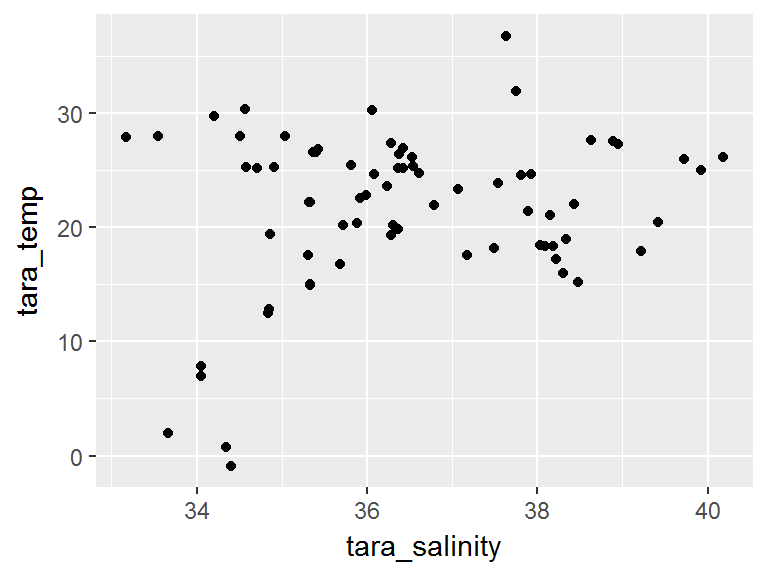

```r
qplot(tara_salinity, tara_temp, data = tara)
```

X vs Y with variation in color of points with size fraction

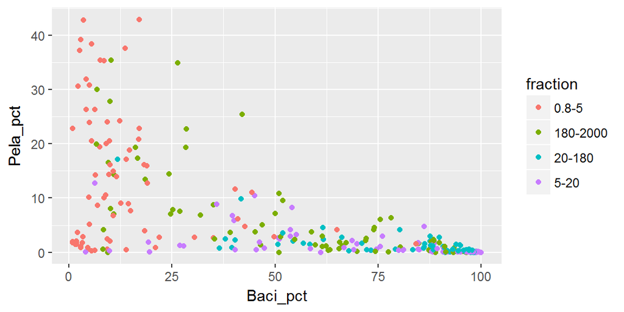

```r
qplot(Baci_pct, Pela_pct, data = tara, color = fraction)
```

X vs Y with variation in color of points with size fraction and shape with depth level

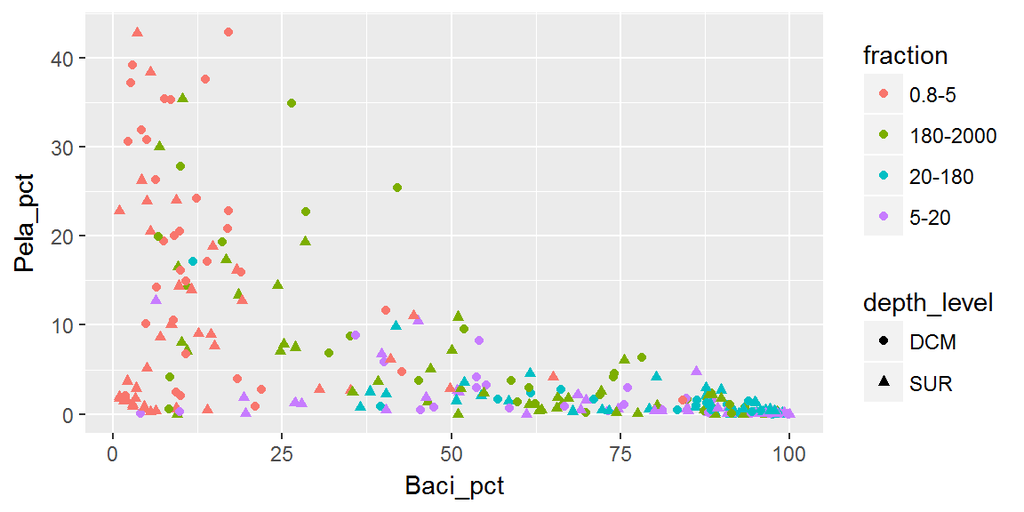

```r
qplot(Baci_pct, Pela_pct, data = tara, color = fraction, shape = depth_level)
```

X vs Y with variation in color of points with size fraction and shape with depth level

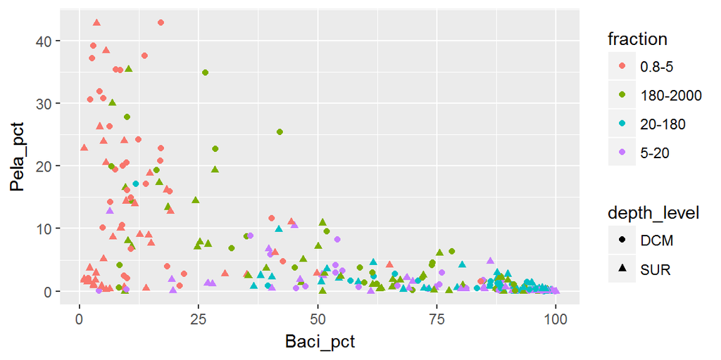

```r
qplot(Baci_pct, Pela_pct, data = tara, color = fraction, shape = depth_level)
```

X vs Y with variation sampling_depth for color of points and shape with with size fraction.

Note that sampling_depth is a **continuous variable**

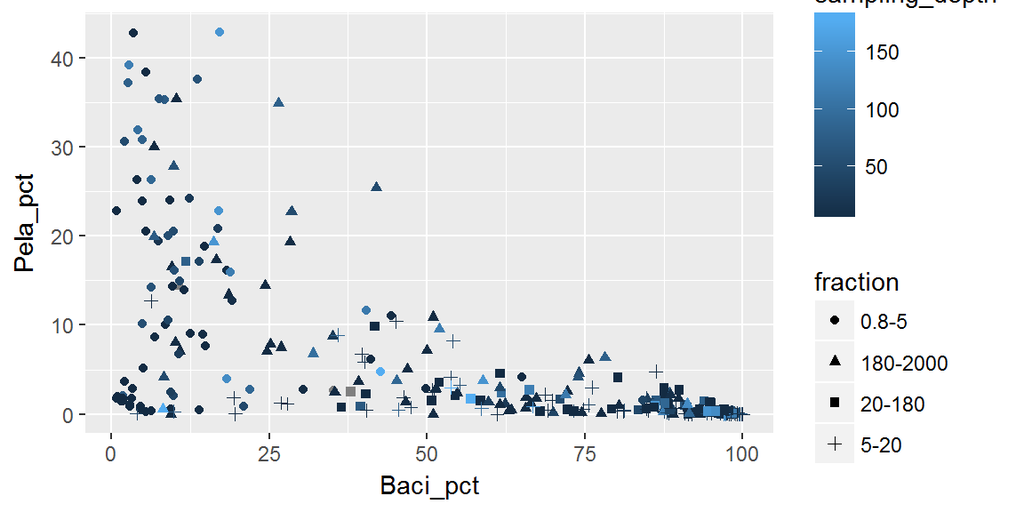

```r
qplot(Baci_pct, Pela_pct, data = tara, color = sampling_depth, shape = fraction)
```

Categorical data vs y with variation in color of points with depth level

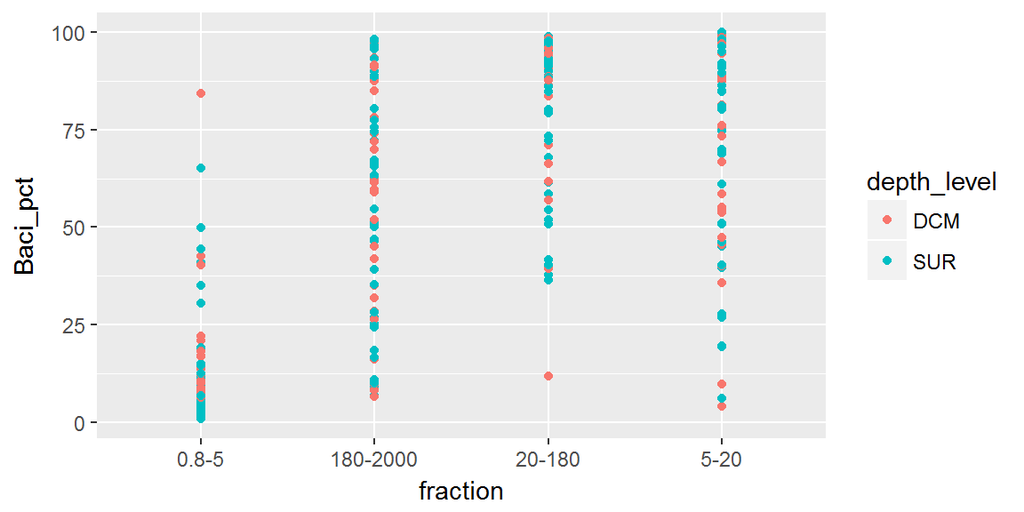

```r
qplot(fraction, Baci_pct, data = tara, color = depth_level)
```

## 4.8 Other types of plots

Boxplot for the same data

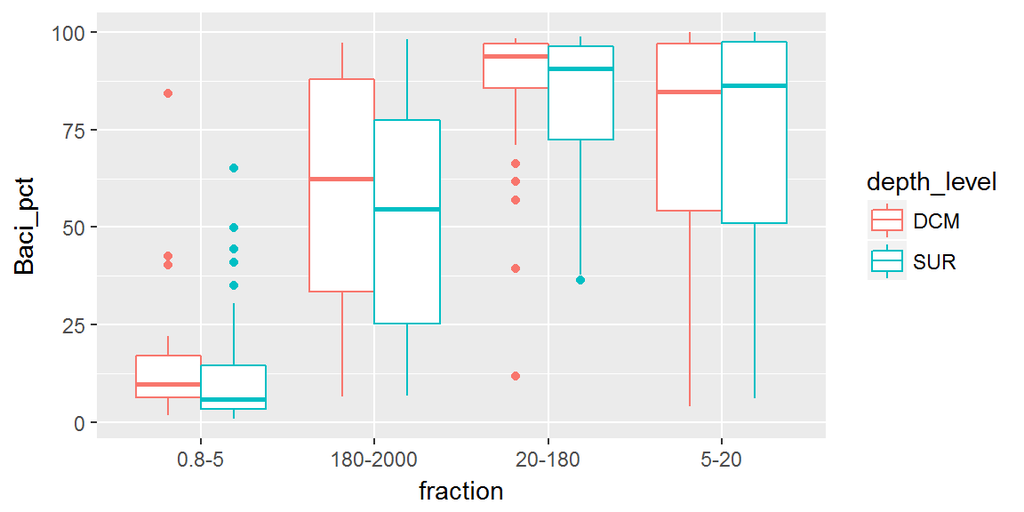

```r
qplot(fraction, Baci_pct, data = tara, color = depth_level, geom = "boxplot")
```

Histogram for all the data

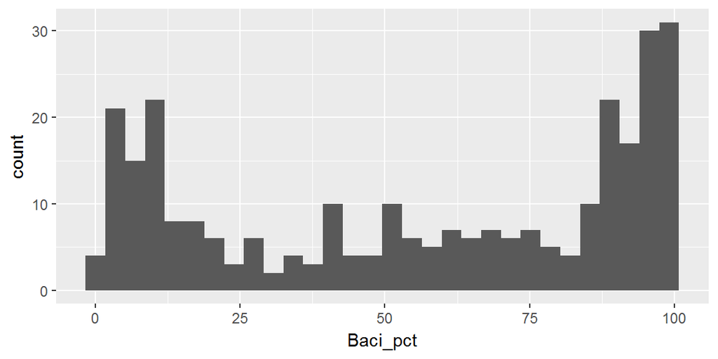

```r
qplot(Baci_pct, data = tara, geom = "histogram")
```

Histogram with different color for each size fraction

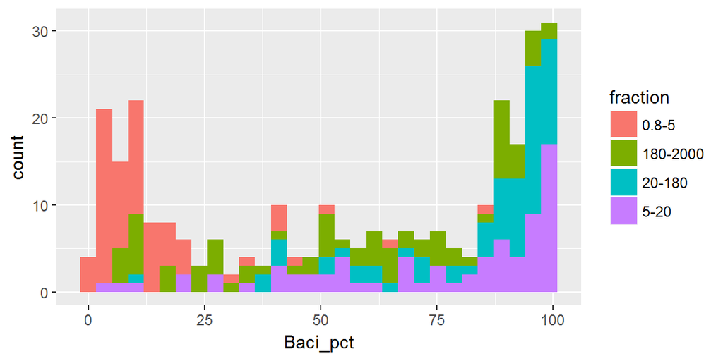

```r
qplot(Baci_pct, data = tara, fill = fraction, geom = "histogram")
```

Histogram with different graphs (facets) for each size fraction and depth and change bin width

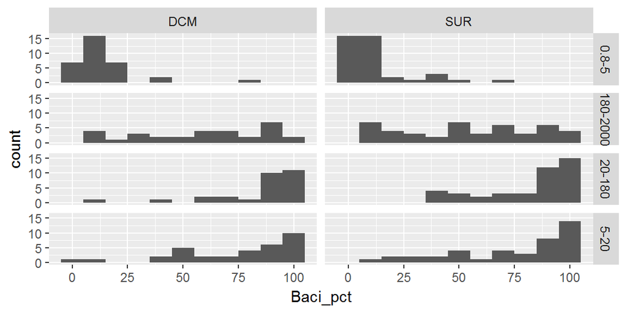

```r
qplot(Baci_pct, data = tara, facets = fraction ~ depth_level, geom = "histogram",
    binwidth = 10)
```

## 4.9 Tree maps (much better than Pie charts…)

```r
library("treemap")  # To do treemaps
```

Reshape the data in order to go from the wide format to go too the long format

```r
tara_tree <- tara %>% select(Sample, depth_level:fraction, Strameno_all, Bacillariophyta:Raphidophyceae) %>%
    gather(key = Class, value = n_seq, Bacillariophyta:Raphidophyceae)
```

Do a global tree map

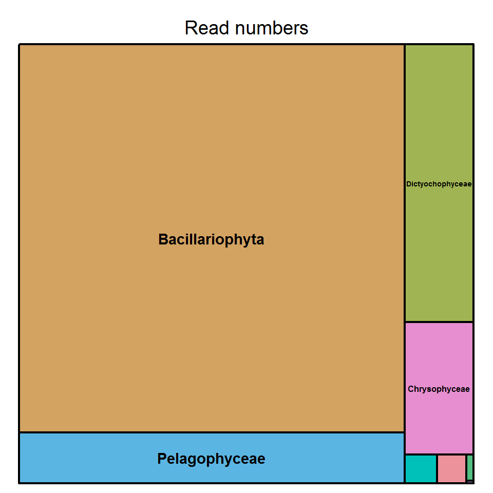

```r
treemap(tara_tree, index = "Class", vSize = "n_seq", title = "Read numbers")
```

Split the tree map according to size fraction

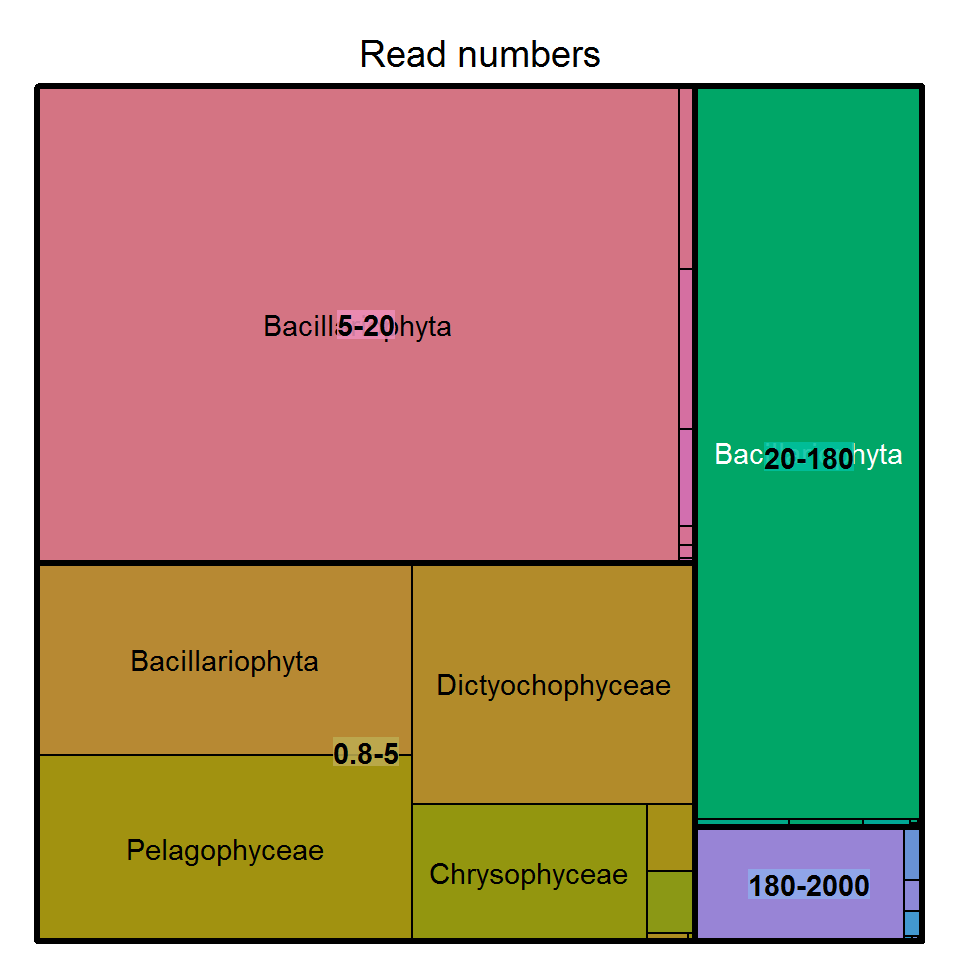

```r
treemap(tara_tree, index = c("fraction", "Class"), vSize = "n_seq", title = "Read numbers")
```

## 4.10 Bar graphs

### 4.10.1 Absolute abundance

Only keep surface samples

```r
tara_bar <- tara_tree %>% filter((depth_level == "SUR") & (fraction == "0.8-5"))
```

Do the bar plot for absolute read numbers  
* Note : rotation of labels : `theme(axis.text.x = element_text(angle = 90, hjust = 1))`

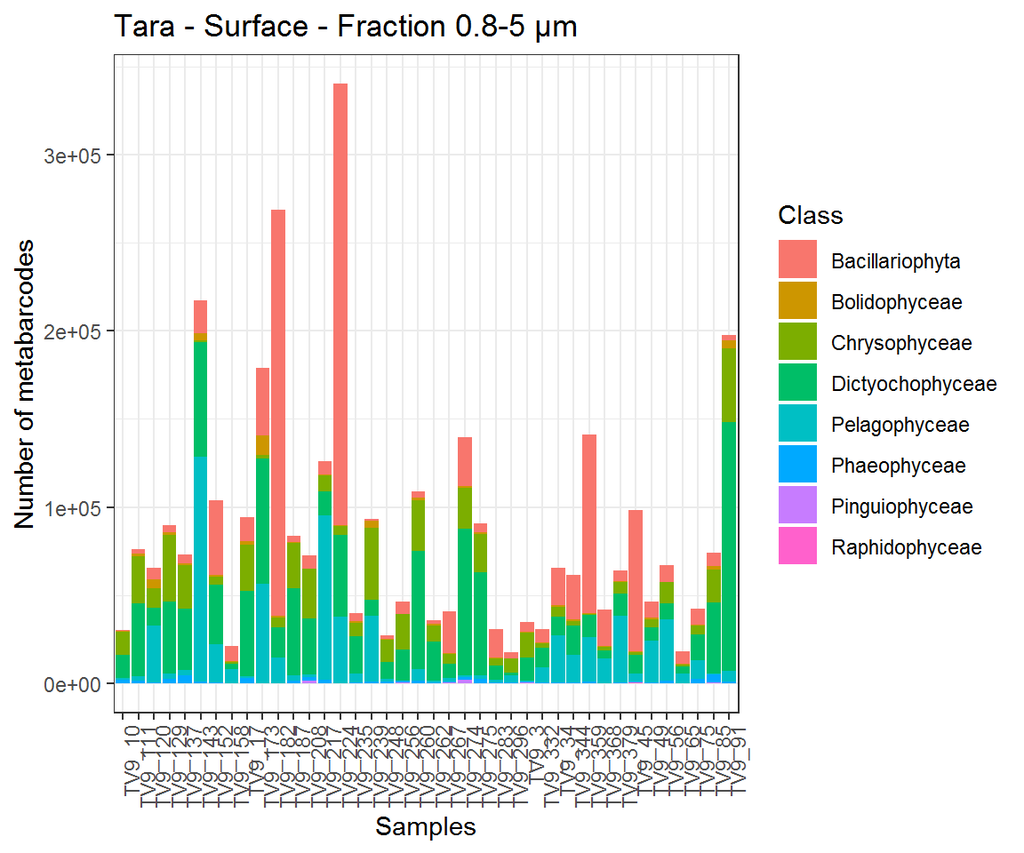

```r
ggplot(tara_bar, aes(x = Sample, y = n_seq, fill = Class)) + geom_bar(stat = "identity") +
    theme_bw() + ggtitle("Tara - Surface - Fraction 0.8-5 µm") + xlab("Samples") +
    ylab("Number of metabarcodes") + theme(axis.text.x = element_text(angle = 90,
    hjust = 1))
```

### 4.10.2 Relative abundance

Compute the relative abundance of each sequence by dividing by the total number of barcodes

```r
tara_bar <- tara_bar %>% mutate(n_seq_rel = n_seq/Strameno_all)
```

Do the bar plot for relative read numbers

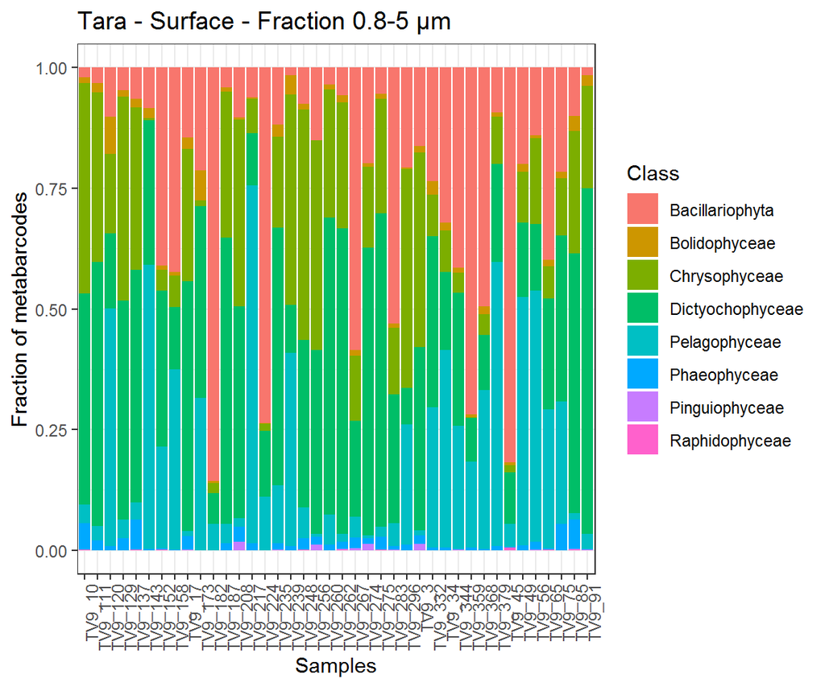

```r
ggplot(tara_bar, aes(x = Sample, y = n_seq_rel, fill = Class)) + geom_bar(stat = "identity") +
    theme_bw() + ggtitle("Tara - Surface - Fraction 0.8-5 µm") + xlab("Samples") +
    ylab("Fraction of metabarcodes") + theme(axis.text.x = element_text(angle = 90,
    hjust = 1))
```

## 4.11 Heat maps

Note : for metabarcoding data use phyloseq package.

Select the fraction and columns (from Bacillariophyta to Raphidophyceae) to be plotted and transform to a matrix

```r
tara_heat <- tara %>% filter(fraction == "0.8-5") %>% select(Bacillariophyta:Raphidophyceae)
tara_heat.matrix <- data.matrix(tara_heat)

# It is necessary to give names to the row for heatmap labels
row.names(tara_heat.matrix) <- tara$station[fraction == "0.8-5"]
```

Draw heatmap

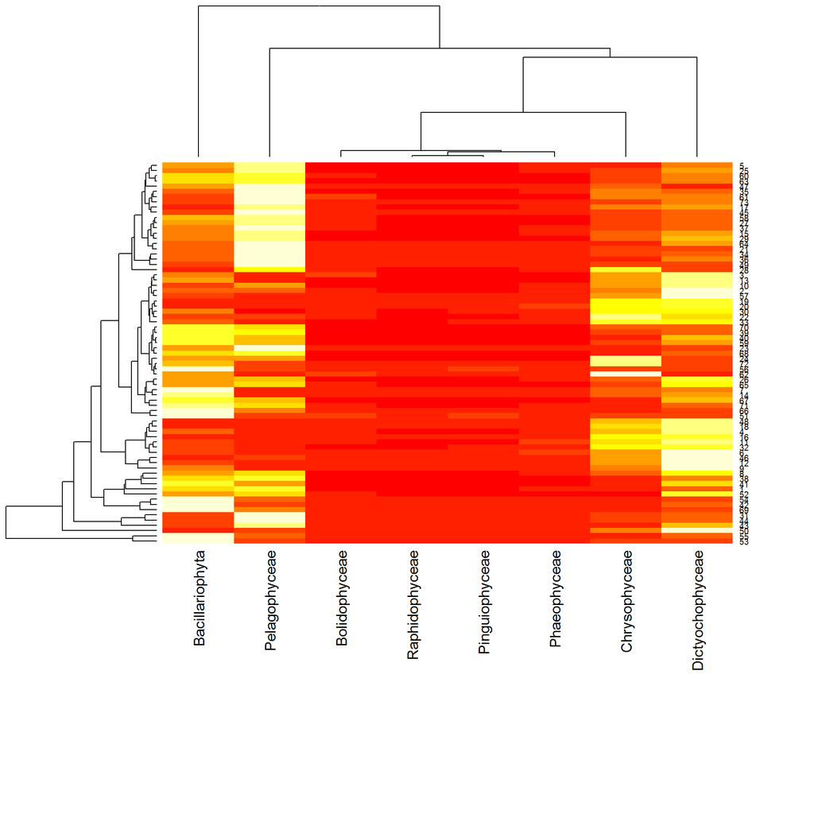

```r
heatmap(tara_heat.matrix, margins = c(20, 6))
```

## 4.12 Multivariate analysis (FactoMiner package)

```r
library("FactoMineR")  # For PCA
```

Principal component analysis (PCA)

```r
# Select only the 0.8-5 µm fraction and only the colums with phytplankon
# data and metadata
tara_multi <- tara %>% filter(fraction == "0.8-5")

# Define row names as 'Station_Depth level' (points with be labelled by row
# names)
row.names(tara_multi) <- paste(tara_multi$station, tara_multi$depth_level, sep = "_")

# Select only with phytoplankon data and metadata
tara_multi <- tara_multi %>% select(Bacillariophyta:Raphidophyceae, chloro_hplc:tara_salinity)

# Scale the matrix
tara_multi <- scale(tara_multi)

# Do the PCA
tara_pca <- PCA(tara_multi)
```

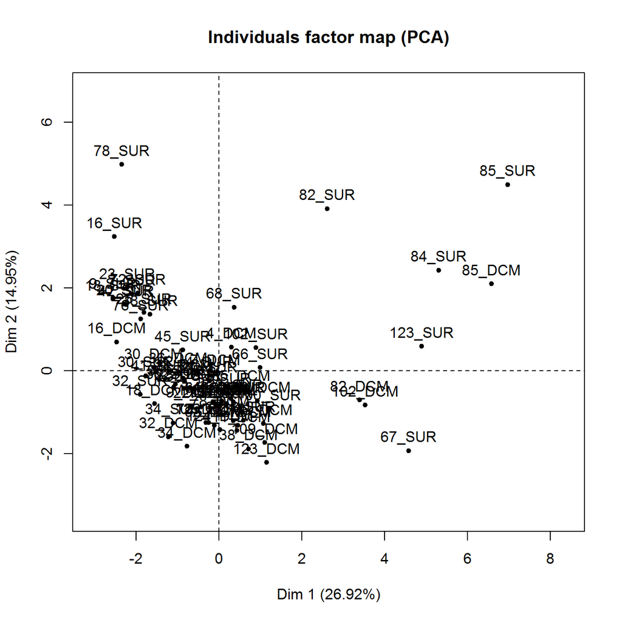

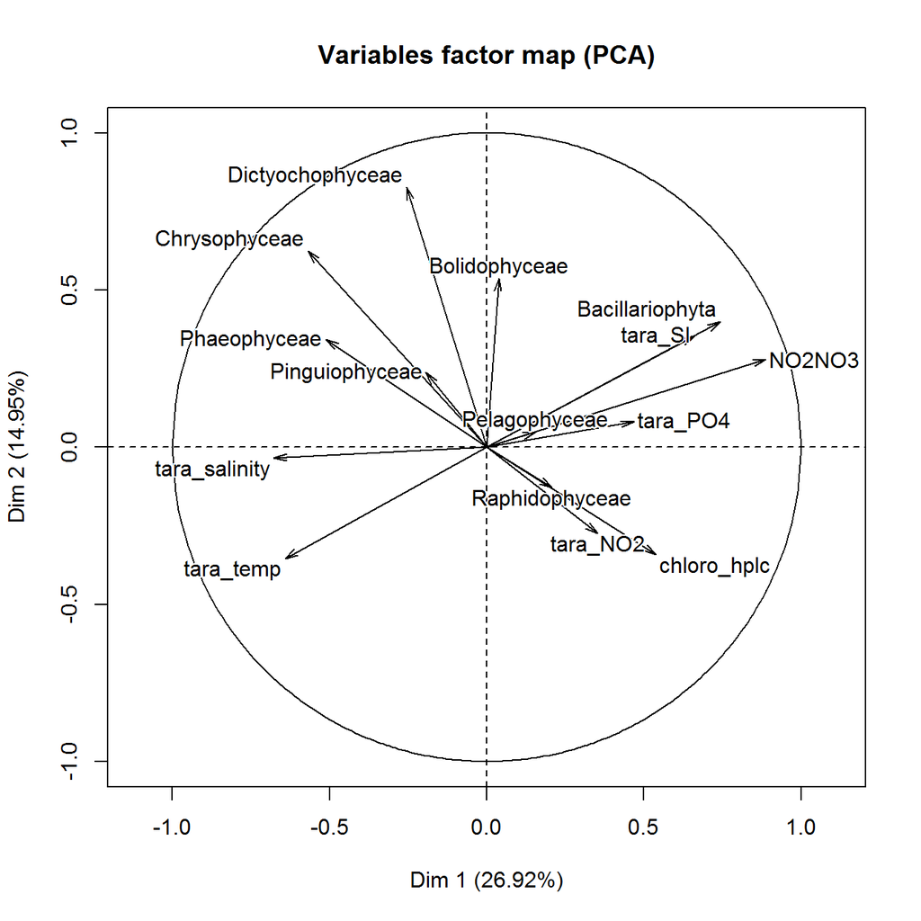

## 4.13 Maps

```r
library("maps")  # Maps
```

Select only surface and small fraction

```r
tara_map <- tara %>% filter((fraction == "0.8-5") & (depth_level == "SUR"))
```

Draw the world map and add the stations

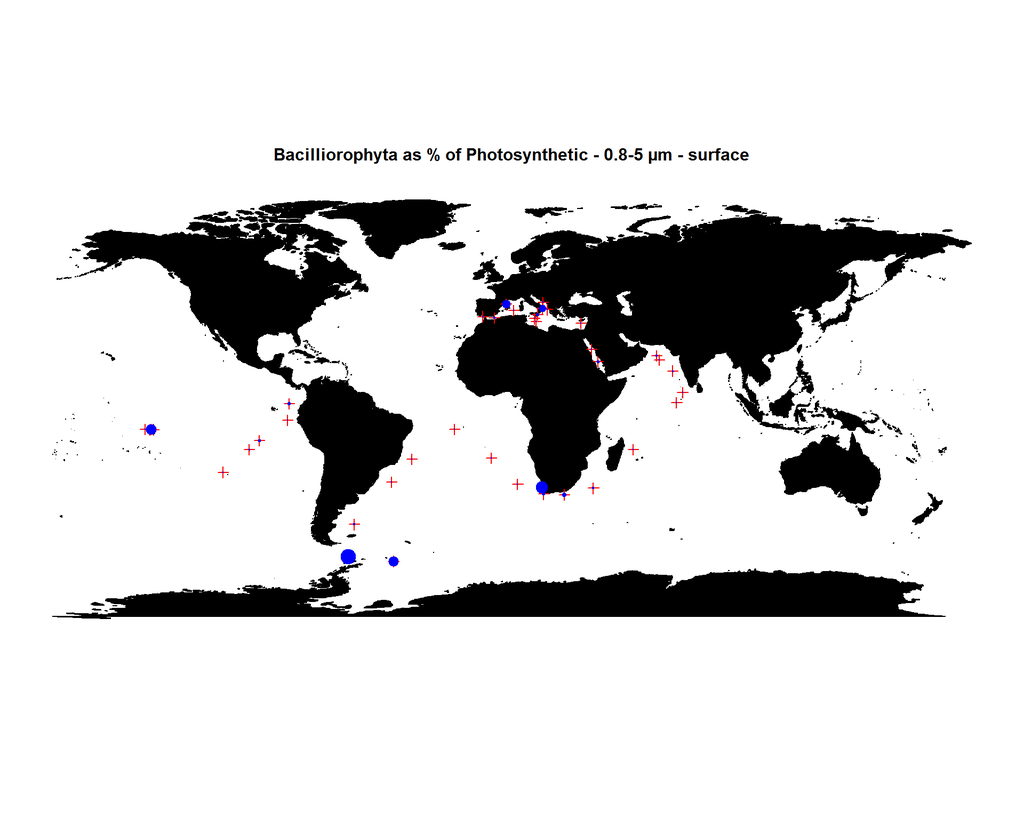

```r
# Draw the world map
map(database = "world", fill = TRUE)

# Add stations
points(tara_map$Longitude, tara_map$Latitude, pch = 3, col = "red", cex = 1)

# Add data - circle size is proprotional to proportion of
points(tara_map$Longitude, tara_map$Latitude, pch = 19, col = "blue", cex = tara_map$Baci_pct *
    3/100)

# Add title
title("Bacilliorophyta as % of Photosynthetic - 0.8-5 µm - surface", cex.main = 1)
```

## 4.14 Manipulate sequences

In BioConductor there are many packages that can process sequences either GenBank or short reads

```r
library("Biostrings")  # To manipulate sequences
```

Read sequences from metagenome (454)

```r
seq <- readDNAStringSet("../data/BIOSOPE_T142_reads_random.fasta", format = "fasta")
```

Compute length of sequence (discard N), compute statistics and plot histogram

```r
Length_seq <- letterFrequency(seq, letters = "ATCG")

range(Length_seq)
```

```
[1]  41 581
```

```r
mean(Length_seq)
```

```
[1] 185.89
```

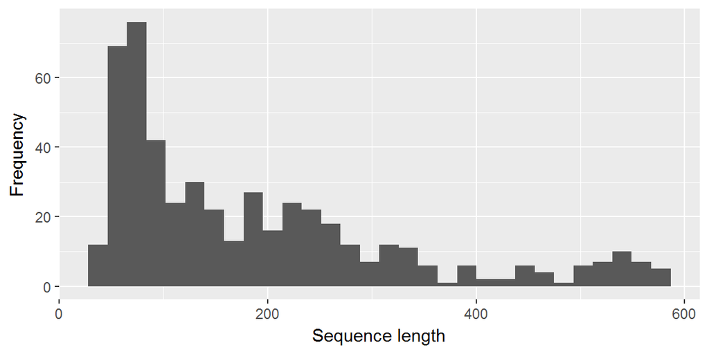

```r
qplot(Length_seq, geom = "histogram", xlab = "Sequence length", ylab = "Frequency")
```

Compute GC% and do simple plots

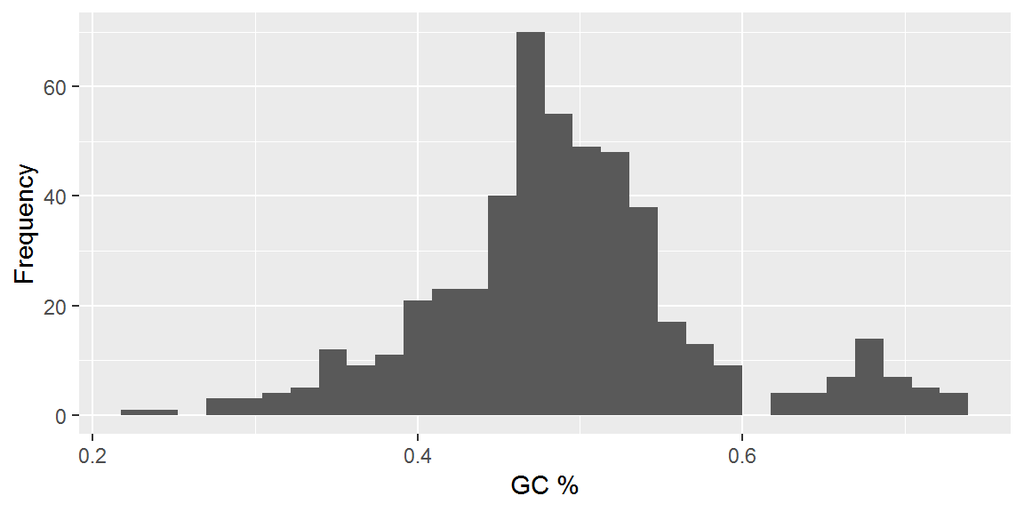

```r
# Compute number of 'GC'
GC_seq <- letterFrequency(seq, letters = "CG")

# Compute GC % in sequence
GC_percent <- GC_seq/Length_seq

# Do histogram
qplot(GC_percent, geom = "histogram", xlab = "GC %", ylab = "Frequency")
```

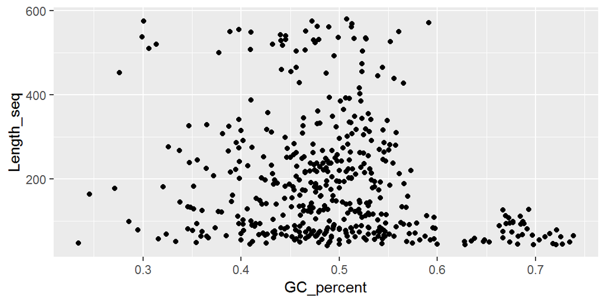

```r
# Plot GC % vs Length of sequence
qplot(GC_percent, Length_seq)
```

**Exercice** : Load sequence from Bathycoccus and compare GC% to that of the whole metagenome

```r
seq <- readDNAStringSet("../data/BIOSOPE_T142_reads_Bathy.fasta", format = "fasta")
```

Daniel Vaulot

25 11 2018